# Tutorium 5 - Folgen (Sequences)

[figure not shown]

*Jochen Illerhaus*

## Fragen

# Folgen und Grenzwerte

- **Folge:** $(a_n)_{n \in \mathbb{N}} = (a_1, a_2, a_3, a_4, a_5, \dots)$. Bsp: $(n^2)_{n \in \mathbb{N}} = (1, 4, 9, 16, 25, 36, \dots)$.
- **Häufingswert:** Wert der in $(a_n)$ mehrfach vorkommt.
- **lim sup**: Größter Häufungswert von $(a_n)$. Schreibweise: $\limsup_{n \rightarrow \infty} a_n$
- **lim inf**: Kleinseter Häufungswert von $(a_n)$. Schreibweise: $\liminf_{n \rightarrow \infty} a_n$
- **Konvergentz:** Falls $(a_n)$ einem Wert $a \in \mathbb{C}$ immer näher kommt, wenn $n$ sehr groß wird: $a_n \rightarrow \lim_{n \rightarrow \infty} a_n = a$. Mathematische definition: $$ \lim_{n \to \infty} a_n = a \; \; \Leftrightarrow \; \; \forall \epsilon > 0: \; \exists N: \; \big| a_n - a \big| < \epsilon \; \forall n \geq N $$
- **Divergend:** falls $(a_n)$ nicht konvergiert, divergiert es.

# Übungsblatt 5 Aufgabe 1a)

Finden Sie Beispiele für Folgen mit den folgenden Eigenschaften:

i) $(a_n)_{n \in \mathbb{N}}$ hat genau die Zahlen $1$ und $−1$ als Häufungswerte.

ii) $(b_n)_{n \in \mathbb{N}}$ hat jede natürliche Zahl als Häufungswert.

iii) $(c_n)_{n \in \mathbb{N}}$ hat keinen Häufungswert und ist weder nach oben noch nach unten beschränkt.

iv) $(d_n)_{n \in \mathbb{N}}$ konvergiert gegen 2018, aber $(d_n)_{n \in \mathbb{N}}$ ist nicht monoton.

v) $(e_n)_{n \in \mathbb{N}}$ hat $0$ als einzigen Häufungswert, jedoch konvergiert $(e_n)_{n \in \mathbb{N}}$ nicht.

(i) $a_n = (-1)^n$

| **$n$** | 1 | 2 | 3 | 4 | 5 | 6 | 7 | 8 | 9 | 10 | 11 | 12 | 13 | 14 | 15 | 16 | 17 | 18 | 19 |
| --- | --- | --- | --- | --- | --- | --- | --- | --- | --- | --- | --- | --- | --- | --- | --- | --- | --- | --- | --- |
| **$a_n$** | -1 | 1 | -1 | 1 | -1 | 1 | -1 | 1 | -1 | 1 | -1 | 1 | -1 | 1 | -1 | 1 | -1 | 1 | -1 |

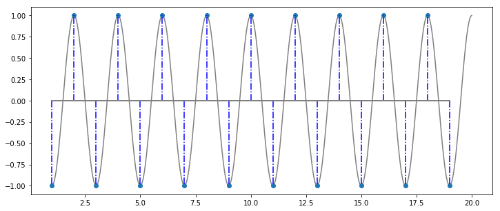

```python
ex1a1()
```

(ii) $b_n = \lceil\frac{n}{2}\rceil$

| **$n$** | 1 | 2 | 3 | 4 | 5 | 6 | 7 | 8 | 9 | 10 | 11 | 12 | 13 | 14 | 15 | 16 | 17 | 18 | 19 |
| --- | --- | --- | --- | --- | --- | --- | --- | --- | --- | --- | --- | --- | --- | --- | --- | --- | --- | --- | --- |
| **$a_n$** | 1 | 1 | 2 | 2 | 3 | 3 | 4 | 4 | 5 | 5 | 6 | 6 | 7 | 7 | 8 | 8 | 9 | 9 | 10 |

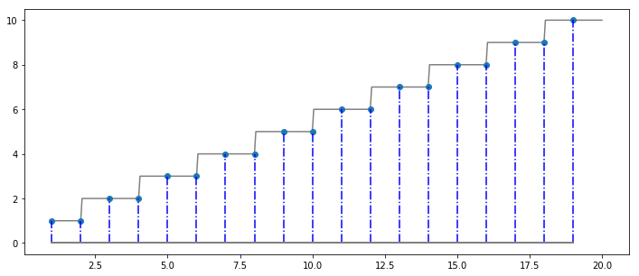

```python
ex1a2()
```

(iii) $c_n = (-1)^n n$

| **$n$** | 1 | 2 | 3 | 4 | 5 | 6 | 7 | 8 | 9 | 10 | 11 | 12 | 13 | 14 | 15 | 16 | 17 | 18 | 19 |
| --- | --- | --- | --- | --- | --- | --- | --- | --- | --- | --- | --- | --- | --- | --- | --- | --- | --- | --- | --- |
| **$a_n$** | -1 | 2 | -3 | 4 | -5 | 6 | -7 | 8 | -9 | 10 | -11 | 12 | -13 | 14 | -15 | 16 | -17 | 18 | -19 |

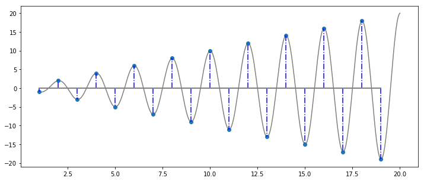

```python
ex1a3()
```

(iv) $d_n = \frac{(-1)^n}{n} + 2018$

| **$n$** | 1 | 2 | 3 | 4 | 5 | 6 | 7 | 8 | 9 | 10 | 11 | 12 | 13 | 14 | 15 | 16 | 17 | 18 | 19 |
| --- | --- | --- | --- | --- | --- | --- | --- | --- | --- | --- | --- | --- | --- | --- | --- | --- | --- | --- | --- |
| **$a_n$** | 2017.0 | 2018.5 | 2017.7 | 2018.2 | 2017.8 | 2018.2 | 2017.9 | 2018.1 | 2017.9 | 2018.1 | 2017.9 | 2018.1 | 2017.9 | 2018.1 | 2017.9 | 2018.1 | 2017.9 | 2018.1 | 2017.9 |

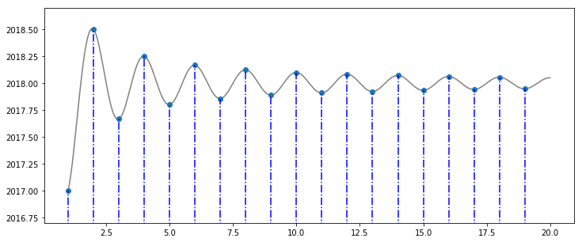

```python
ex1a4()
```

(v) $e_n = \frac n4 \big( ( -1 )^n + 1\big)$

| **$n$** | 1 | 2 | 3 | 4 | 5 | 6 | 7 | 8 | 9 | 10 | 11 | 12 | 13 | 14 | 15 | 16 | 17 | 18 | 19 |
| --- | --- | --- | --- | --- | --- | --- | --- | --- | --- | --- | --- | --- | --- | --- | --- | --- | --- | --- | --- |
| **$a_n$** | 0 | 1 | 0 | 2 | 0 | 3 | 0 | 4 | 0 | 5 | 0 | 6 | 0 | 7 | 0 | 8 | 0 | 9 | 0 |

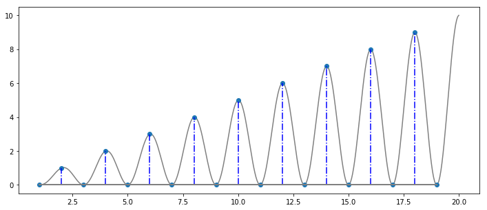

```python
ex1a5()
```

# Übungsblatt 5 Aufgabe 1b)

Entscheiden Sie jeweils durch Beweis oder Gegenbeispiel, ob die Folge $(a_n)_{n \in \mathbb{N}}$ konvergiert, falls es zu jedem $\epsilon > 0$ ein $n_0 \in \mathbb{N}$ gibt so, dass für alle $n>n_0$ gilt:

**i)** $$\big| a_n − a_{n+1} \big|< \epsilon$$

**ii)** $$\big| a_n \big| < 2 \epsilon^2$$

**iii)** $$\big| a_n + a_{n+1} \big|< \epsilon$$

**iv)** $$\big| a_n a_{n+1} \big| < \epsilon$$

**v)** $$\big| a_n a_m \big| < \epsilon \;\; \text{für alle} \;\; m \in \mathbb{N}$$

# Übungsblatt 5 Aufgabe 2

Bestimmen Sie alle Häufungswerte von $(a_n)_{n \in \mathbb{N}}$ und geben Sie $\liminf_{n \rightarrow \infty}(a_n)$ und $\limsup_{n \rightarrow \infty}(a_n)$ an.

**a)** $$ a_n = \bigg(1 + \big( −1 \big)^n \bigg)^n $$

**b)** $$ a_n = \Bigg\{ \begin{array}{ll} 1 + 1/2^n & \;\; n = 3k \;\; \text{für ein} \;\; k \in \mathbb{N} \\ 2 & \;\; n = 3k-1 \;\; \text{für ein} \;\; k \in \mathbb{N} \\ 2 + (n+1)/n & \;\; n = 3k-2 \;\; \text{für ein} \;\; k \in \mathbb{N} \end{array} $$

(a) $a_n = \bigg(1 + \big( −1 \big)^n \bigg)^n$

| **$n$** | 1 | 2 | 3 | 4 | 5 | 6 | 7 | 8 | 9 | 10 | 11 | 12 | 13 | 14 | 15 | 16 | 17 | 18 | 19 |
| --- | --- | --- | --- | --- | --- | --- | --- | --- | --- | --- | --- | --- | --- | --- | --- | --- | --- | --- | --- |
| **$a_n$** | 0 | 4 | 0 | 16 | 0 | 64 | 0 | 256 | 0 | 1024 | 0 | 4096 | 0 | 16384 | 0 | 65536 | 0 | 262144 | 0 |

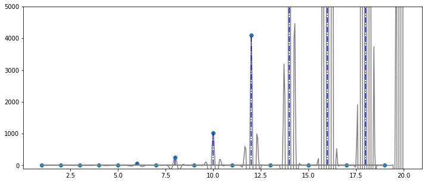

```python
ex2a()
```

(b) $b_n$

| **$n$** | 1 | 2 | 3 | 4 | 5 | 6 | 7 | 8 | 9 | 10 | 11 | 12 | 13 | 14 | 15 | 16 | 17 | 18 | 19 |
| --- | --- | --- | --- | --- | --- | --- | --- | --- | --- | --- | --- | --- | --- | --- | --- | --- | --- | --- | --- |
| **$a_n$** | 4.00 | 2.00 | 1.12 | 3.25 | 2.00 | 1.02 | 3.14 | 2.00 | 1.00 | 3.10 | 2.00 | 1.00 | 3.08 | 2.00 | 1.00 | 3.06 | 2.00 | 1.00 | 3.05 |

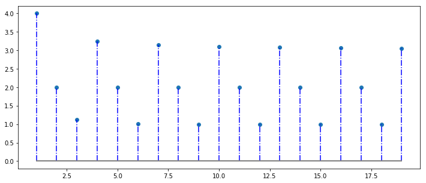

```python
ex2b()
```

# Übungsblatt 5 Aufgabe 5

**a)** Es sei $(a_n)_{n \in \mathbb{N}}$ eine konvergente Folge. Zeigen Sie, dass dann jede Teilfolge von $(a_n)_{n \in \mathbb{N}}$ konvergiert und zwar gegen den selben Grenzwert.

**b)** Beweisen Sie: Besitzt eine Folge $(a_n)_{n \in \mathbb{N}}$ eine divergente Teilfolge, so divergiert $(a_n)_{n \in \mathbb{N}}$.

**c)** Die Folge $(a_n)_{n \in \mathbb{N}}$ besitze die konvergenten Teilfolgen $(a_{2n})_{n \in \mathbb{N}}$ und $(a_{2n+1})_{n \in \mathbb{N}}$. Folgt hieraus die Konvergenz von $(a_n)_{n \in \mathbb{N}}$? Begründen Sie Ihre Antwort.

**d)** Zeigen Sie, dass eine Folge $(a_n)_{n \in \mathbb{N}}$ genau dann konvergiert, wenn die drei Teilfolgen $(a_{2n})_{n \in \mathbb{N}}$, $(a_{2n+1})_{n \in \mathbb{N}}$ und $(a_{3n})_{n \in \mathbb{N}}$ konvergieren.